# Dummy Variables

Natasha Kang

Xiamen University, Chow Institute

April, 2026

## Roadmap

1. **Dummy variables as regressors**: intercept shifts, slope shifts, multiple categories
2. Testing for structural differences (Chow test)
3. The linear probability model

## Qualitative Information in Regression

- So far, all regressors have been quantitative (wages, education years, rooms).
- But many important factors are qualitative: gender, marital status, region, industry.
- OLS requires numerical inputs. We encode qualitative information using **dummy variables** (also called indicator variables):

$$\text{female}_i = \begin{cases} 1 & \text{if person } i \text{ is a woman} \\ 0 & \text{if person } i \text{ is a man} \end{cases}$$

## A Single Dummy Variable: Intercept Shift

Consider:

$$\text{wage}_i = \beta_0 + \delta_0\, \text{female}_i + \beta_1\, \text{educ}_i + u_i$$

For men ($\text{female}_i = 0$):

$$E[\text{wage}_i \mid \text{female}_i = 0,\, \text{educ}_i] = \beta_0 + \beta_1\, \text{educ}_i$$

For women ($\text{female}_i = 1$):

$$E[\text{wage}_i \mid \text{female}_i = 1,\, \text{educ}_i] = (\beta_0 + \delta_0) + \beta_1\, \text{educ}_i$$

$\delta_0$ is the **intercept shift**: the wage difference between women and men, holding education constant.

## Visualizing the Intercept Shift

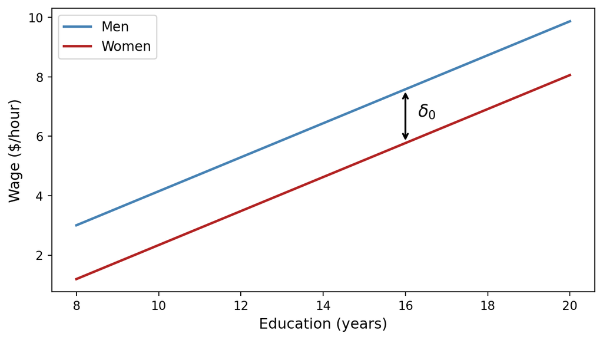

The dummy shifts the intercept — the two groups have **parallel** regression lines.

## Example: Gender Wage Gap

Data: *wage1*

$$\begin{aligned}
\widehat{\text{wage}} = \underset{(0.72)}{-1.57} &\underset{(0.26)}{- 1.81}\; \text{female} + \underset{(0.049)}{0.572}\; \text{educ} \\
&+ \underset{(0.012)}{0.025}\; \text{exper} + \underset{(0.021)}{0.141}\; \text{tenure}
\end{aligned}$$

- $\hat\delta_0 = -1.81$: a woman earns $1.81/hour less than a man with the same education, experience, and tenure.
- The $t$-statistic is $-1.81/0.26 = -6.96$ — highly significant.

## Dummies with a Log Dependent Variable

$$\log(\text{wage}) = \beta_0 + \delta_0\, \text{female} + \beta_1\, \text{educ} + \cdots + u_i$$

From lect4a, the coefficient on a dummy in a log model has a percentage interpretation:

$$\delta_0 = \log(\text{wage}^F) - \log(\text{wage}^M) = \log\!\left(\frac{\text{wage}^F}{\text{wage}^M}\right) \approx \frac{\text{wage}^F - \text{wage}^M}{\text{wage}^M}$$

For large differences, use the exact formula: $\%\Delta = 100 \cdot [\exp(\hat\delta_0) - 1]$.

## Example: Log Wage Equation

Data: *wage1*

$$\begin{aligned}
\widehat{\log(\text{wage})} = \underset{(0.099)}{0.417} &\underset{(0.036)}{- 0.297}\; \text{female} + \underset{(0.007)}{0.080}\; \text{educ} \\
&+ \underset{(0.005)}{0.029}\; \text{exper} \underset{(0.00010)}{- 0.00058}\; \text{exper}^2 \\
&+ \underset{(0.007)}{0.032}\; \text{tenure} \underset{(0.00023)}{- 0.00059}\; \text{tenure}^2
\end{aligned}$$

- Approximate: women earn $29.7\%$ less than comparable men.
- Exact: $100 \cdot [\exp(-0.297) - 1] = -25.7\%$.
- The approximation overstates the gap because $|\hat\delta_0| = 0.297$ is not small.

## The Base Group and Changing It

Men are the **base group** — the omitted category. The dummy coefficient measures the difference relative to this group.

What if we use $\text{male}_i$ instead?

$$\log(\text{wage}) = \theta_0 + \gamma_0\, \text{male}_i + \beta_1\, \text{educ} + u_i$$

Since $\text{male}_i = 1 - \text{female}_i$, matching coefficients gives:

$$\gamma_0 = -\delta_0, \quad \theta_0 = \beta_0 + \delta_0$$

Changing the base group flips the sign of the dummy coefficient — it does not change the substance.

## The Dummy Variable Trap

What if we include *both* $\text{female}_i$ and $\text{male}_i$ along with an intercept?

$$\log(\text{wage}) = \alpha_0 + \delta_0\, \text{female}_i + \gamma_0\, \text{male}_i + \beta_1\, \text{educ} + u_i$$

Since $\text{female}_i + \text{male}_i = 1$ for all $i$, the three “regressors” (intercept, female, male) are **perfectly collinear**. OLS cannot be computed.

**Rule**: for a binary qualitative variable, include one dummy and omit the other. The omitted category is the base group.

## Multiple Categories

Qualitative variables often have more than two levels (e.g., race, region, education level).

**Example**: marital status with 3 categories — married, single, divorced.

$$\text{wage} = \beta_0 + \delta_1\, \text{single}_i + \delta_2\, \text{divorced}_i + \beta_1\, \text{educ} + u_i$$

- Married is the base group.
- $\delta_1$: wage difference between single and married workers.
- $\delta_2$: wage difference between divorced and married workers.

**General rule**: a qualitative variable with $m$ categories requires $m - 1$ dummy variables.

## Roadmap

1. **Dummy variables as regressors**: intercept shifts, **slope shifts**, multiple categories
2. Testing for structural differences (Chow test)
3. The linear probability model

## Slope Shifts: Dummy–Continuous Interactions

An intercept shift assumes the return to education is the same for men and women. What if it differs?

$$\log(\text{wage}) = \beta_0 + \delta_0\, \text{female} + \beta_1\, \text{educ} + \delta_1\, (\text{female} \cdot \text{educ}) + u_i$$

For men:

$$\log(\text{wage}^M) = \beta_0 + \beta_1\, \text{educ}$$

For women:

$$\log(\text{wage}^F) = (\beta_0 + \delta_0) + (\beta_1 + \delta_1)\, \text{educ}$$

$\delta_1$ measures the **difference in the return to education** between women and men.

## Visualizing the Slope Shift

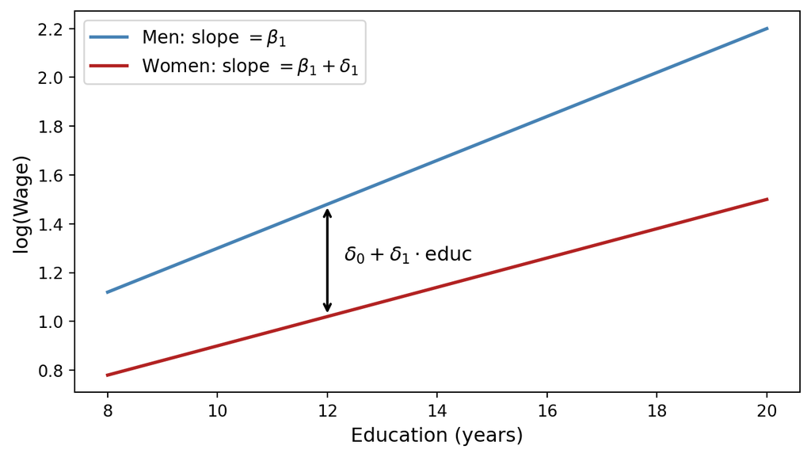

With a slope shift, the two groups have **different slopes** — the lines are no longer parallel.

## Example: Returns to Education by Gender

Data: *wage1*

$$\begin{aligned}
\widehat{\log(\text{wage})} = \underset{(0.119)}{0.389} &\underset{(0.168)}{- 0.227}\; \text{female} + \underset{(0.008)}{0.082}\; \text{educ} \\
&\underset{(0.0131)}{- 0.0056}\; \text{female} \cdot \text{educ} \\
&+ \underset{(0.005)}{0.029}\; \text{exper} \underset{(0.00011)}{- 0.00058}\; \text{exper}^2 \\
&+ \underset{(0.007)}{0.032}\; \text{tenure} \underset{(0.00024)}{- 0.00059}\; \text{tenure}^2
\end{aligned}$$

- $\hat\delta_1 = -0.0056$: the return to education for women is 0.56 percentage points lower than for men.
- But $t = -0.0056/0.0131 = -0.43$ — not significant. We cannot reject equal returns to education.

## Interactions Among Dummy Variables

What about interactions between two dummies?

$$\begin{aligned}
\widehat{\log(\text{wage})} = \underset{(.100)}{.321} &\underset{(.056)}{- .110}\; \text{female} + \underset{(.055)}{.231}\; \text{married} \\
&\underset{(.072)}{- .301}\; \text{female} \cdot \text{married} + \cdots
\end{aligned}$$

This creates four groups:

|  | Single | Married |
| --- | --- | --- |
| **Men** (base) | $0.321$ | $0.321 + 0.231 = 0.552$ |
| **Women** | $0.321 - 0.110 = 0.211$ | $0.321 - 0.110 + 0.231 - 0.301 = 0.141$ |

The marriage premium is $0.231$ for men but $0.231 - 0.301 = -0.070$ for women. Marriage is associated with *higher* wages for men but *lower* wages for women.

## Roadmap

1. Dummy variables as regressors: intercept shifts, slope shifts, multiple categories
2. **Testing for structural differences (Chow test)**
3. The linear probability model

## Are Two Groups Truly Different?

So far we’ve tested individual dummy coefficients. But what if we want to test whether **all** coefficients differ across groups?

**Example**: do the wage equations for men and women differ in *any* way — intercept, returns to education, returns to experience, etc.?

This is a **joint test** of all dummy coefficients and their interactions:

$$H_0: \delta_0 = \delta_1 = \cdots = \delta_k = 0$$

## The Chow Test via Dummies

Include a group dummy and its interaction with every regressor:

$$y_i = \beta_0 + \beta_1 x_{1i} + \cdots + \beta_k x_{ki} + \delta_0 D_i + \delta_1 D_i x_{1i} + \cdots + \delta_k D_i x_{ki} + u_i$$

- **Unrestricted model**: the equation above (allows all coefficients to differ).
- **Restricted model**: drop all $\delta$ terms (forces identical coefficients across groups).

Test $H_0: \delta_0 = \delta_1 = \cdots = \delta_k = 0$ using the $F$-statistic:

$$F = \frac{(SSR_r - SSR_{ur}) / (k+1)}{SSR_{ur} / (n - 2(k+1))} \sim F_{k+1,\; n - 2(k+1)}$$

This is just the **exclusion restriction $F$-test** from lect3a — nothing new. Under heteroskedasticity, use a robust version of the joint test.

## Equivalence: Separate Regressions

An equivalent approach: estimate **separate** regressions for each group.

$$\begin{aligned}
y_i &= \beta_{1,0} + \beta_{1,1} x_{1i} + \cdots + \beta_{1,k} x_{ki} + u_i \quad \text{(group 1)} \\
y_i &= \beta_{2,0} + \beta_{2,1} x_{1i} + \cdots + \beta_{2,k} x_{ki} + u_i \quad \text{(group 2)}
\end{aligned}$$

Then $SSR_{ur} = SSR_1 + SSR_2$, and the Chow $F$-statistic is:

$$F = \frac{(SSR_p - SSR_1 - SSR_2) / (k+1)}{(SSR_1 + SSR_2) / (n_1 + n_2 - 2(k+1))}$$

where $SSR_p$ is the SSR from the pooled (single-equation) regression.

Both approaches — dummy interactions and separate regressions — yield the same $F$-statistic.

## Roadmap

1. Dummy variables as regressors: intercept shifts, slope shifts, multiple categories
2. Testing for structural differences (Chow test)
3. **The linear probability model**

## When the Dependent Variable Is Binary

So far, dummies have been regressors. But the dependent variable can also be binary:

- Whether an individual is employed or not
- Whether a borrower defaults on a loan
- Whether a student is admitted to a university

If $y_i \in \{0, 1\}$, then $E[y \mid \mathbf{x}] = P(y = 1 \mid \mathbf{x})$ — the conditional mean *is* the probability. If we model this probability as linear:

$$P(y = 1 \mid \mathbf{x}) = \beta_0 + \beta_1 x_1 + \cdots + \beta_k x_k$$

this is the **linear probability model** (LPM). Estimation is OLS as before.

## Example: Labor Force Participation

Data: *mroz*

$$\begin{aligned}
\widehat{\text{inlf}} = \underset{(.154)}{.586} &\underset{(.0014)}{- .0034}\; \text{nwifeinc} + \underset{(.007)}{.038}\; \text{educ} \\
&+ \underset{(.006)}{.039}\; \text{exper} \underset{(.00018)}{- .00060}\; \text{exper}^2 \\
&\underset{(.002)}{- .016}\; \text{age} \underset{(.034)}{- .262}\; \text{kidslt6} + \underset{(.013)}{.013}\; \text{kidsge6}
\end{aligned}$$

- $\hat\beta_{\text{kidslt6}} = -0.262$: one additional child under 6 reduces the probability of being in the labor force by 26.2 percentage points.
- $\hat\beta_{\text{educ}} = 0.038$: one more year of education increases the probability by 3.8 percentage points.
- Coefficients measure changes in **probability**, not in a continuous outcome.

## Shortcomings of the LPM

The LPM can predict probabilities **outside** $[0, 1]$:

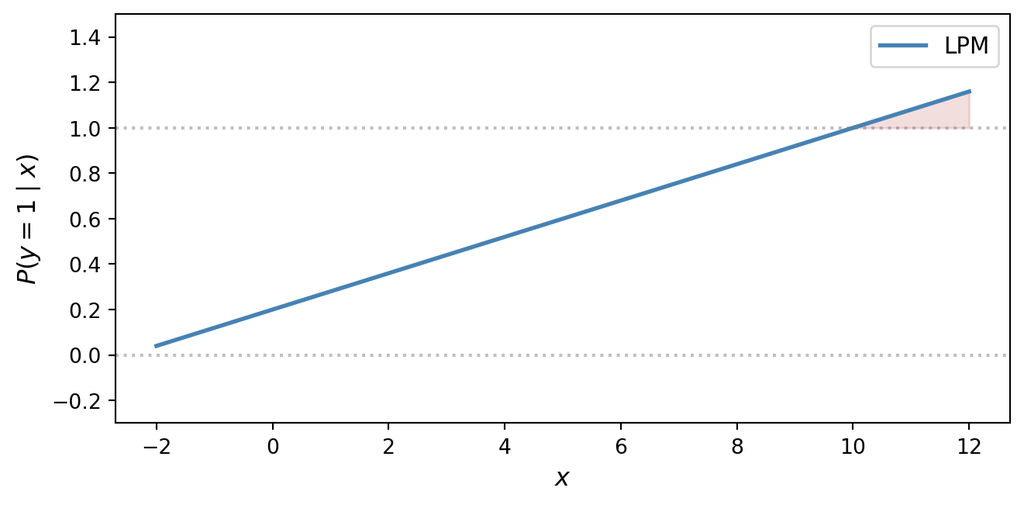

- Predicted probabilities can be negative or exceed 1 — nonsensical.
- The LPM also assumes a constant marginal effect, which may be unrealistic near the boundaries.

## The LPM Is Heteroskedastic by Construction

Since $y_i \in \{0, 1\}$:

$$\text{Var}(y \mid \mathbf{x}) = P(y = 1 \mid \mathbf{x})\, [1 - P(y = 1 \mid \mathbf{x})]$$

Under the LPM, $P(y = 1 \mid \mathbf{x}) = \mathbf{x}'\boldsymbol{\beta}$, so:

$$\text{Var}(u \mid \mathbf{x}) = (\mathbf{x}'\boldsymbol{\beta})(1 - \mathbf{x}'\boldsymbol{\beta})$$

The error variance depends on $\mathbf{x}$ — **heteroskedasticity is built in**, not a special case.

This is an instance of what we saw in lect3b: the model structure itself can generate heteroskedasticity. Always use **heteroskedasticity-robust standard errors** with the LPM.

## When Is the LPM Still Useful?

Despite its shortcomings:

- The LPM works well for values of $\mathbf{x}$ near the sample mean, where predicted probabilities are away from the boundaries.
- It is easy to estimate, interpret, and extend with the same tools (OLS, $t$-tests, $F$-tests).
- For many policy questions, the marginal effect at the mean is the quantity of interest — and the LPM delivers this directly.

For applications where boundary behavior matters, nonlinear alternatives (logit, probit) constrain probabilities to $[0, 1]$. These require maximum likelihood estimation — beyond the scope of this course.

## Summary

- **Dummy variables** encode qualitative information as 0/1 regressors. With $m$ categories, use $m - 1$ dummies.
- An intercept dummy **shifts** the regression line; a dummy–continuous interaction allows **different slopes** across groups.
- The **Chow test** checks whether all coefficients differ across groups — it is an $F$-test on the joint significance of all dummy interactions.
- The **LPM** applies OLS to a binary outcome. Coefficients measure changes in probability. Use robust standard errors because the model is heteroskedastic by construction.

## What’s Next

**Lecture 4c — Model Selection & Controls**:

- Bias-variance tradeoff and adjusted $R^2$
- Specification testing (RESET)
- Good controls vs. bad controls